# Human Trafficking Hackathon Notebook

This project seeks to find statsitical relationships in a survey done on the subject of Human Trafficking in Fiji by the UN Office on Drugs and Crime (UNODC). UNODC recently surveyed 1,000 people in Fiji about their experiences with trafficking in persons. The questionnaire, deployed in partnership with the Fijian Bureau of Statistics, touched upon trafficking for forced labour, sexual exploitation, and forced marriage. Estimating the prevalence of human trafficking is dearly needed and yet rarely done as very difficult in terms of methodology. In addition, technology can support data analysis and visualization which in turn contributes to understanding the phenomenon its root causes. The research questions that we are asking are:

1. Do any geographical areas based on population density have significantly more or less prevalance of human trafficking?
2. Are there any social or demographic factors which tend to be predictive of higher incidences of human trafficking

The end goal of the research is to create a product which can be reused in other nations and help the UNODC identify root causes of trafficking and reduce or eliminate the problem

First, import any needed libraries

```r
library(tidyverse)
library(ggplot2)
library(readxl)
library(shiny)
```

Next, import the provided dataset from the Fiji survey

```r
fiji_data <- read_excel("data/UNODC_Data_Fiji_Human_Trafficking.xlsx")
```

```r
fiji_data$currentwork <- as.numeric(sub("^(\\d{1}).*$", "\\1", fiji_data$currentwork))
fiji_filtered <- fiji_data %>% filter(currentwork == 1)
```

```r
fiji_subset <- fiji_filtered %>% select(interview__id, province, lesspay_2a, typeofwork,
                                    workinghrs, pressured, threatened, harmed, threatened_pay,
                                    threatened_report, id_papers, comm_family, lesspay_11a,
                                    workinghrs_11c, pressured_11d, threatened_11e, harmed_11f,
                                    threatened_pay_11g, threatened_report_11h, id_papers_11i,
                                    comm_family_11j, comm_others_11k, yes_number_12k)
```

It will probably be helpful to compute the percentage of yes and no responses for each province. Let’s convert the strings to numeric values by only keeping the first character of each string in the columns and then convert that string to a numeric.

```r
fiji_subset$lesspay_2a <- as.numeric(sub("^(\\d{1}).*$", "\\1", fiji_subset$lesspay_2a))
fiji_subset$typeofwork <- as.numeric(sub("^(\\d{1}).*$", "\\1", fiji_subset$typeofwork))
fiji_subset$workinghrs <- as.numeric(sub("^(\\d{1}).*$", "\\1", fiji_subset$workinghrs))
fiji_subset$pressured <- as.numeric(sub("^(\\d{1}).*$", "\\1", fiji_subset$pressured))
fiji_subset$threatened <- as.numeric(sub("^(\\d{1}).*$", "\\1", fiji_subset$threatened))
fiji_subset$harmed <- as.numeric(sub("^(\\d{1}).*$", "\\1", fiji_subset$harmed))
fiji_subset$threatened_pay <- as.numeric(sub("^(\\d{1}).*$", "\\1", fiji_subset$threatened_pay))
fiji_subset$threatened_report <- as.numeric(sub("^(\\d{1}).*$", "\\1", fiji_subset$threatened_report))
fiji_subset$id_papers <- as.numeric(sub("^(\\d{1}).*$", "\\1", fiji_subset$id_papers))
fiji_subset$comm_family <- as.numeric(sub("^(\\d{1}).*$", "\\1", fiji_subset$comm_family))
fiji_subset$lesspay_11a <- as.numeric(sub("^(\\d{1}).*$", "\\1", fiji_subset$lesspay_11a))
fiji_subset$workinghrs_11c <- as.numeric(sub("^(\\d{1}).*$", "\\1", fiji_subset$workinghrs_11c))
fiji_subset$pressured_11d <- as.numeric(sub("^(\\d{1}).*$", "\\1", fiji_subset$pressured_11d))
fiji_subset$threatened_11e <- as.numeric(sub("^(\\d{1}).*$", "\\1", fiji_subset$threatened_11e))
fiji_subset$harmed_11f <- as.numeric(sub("^(\\d{1}).*$", "\\1", fiji_subset$harmed_11f))
fiji_subset$threatened_pay_11g <- as.numeric(sub("^(\\d{1}).*$", "\\1", fiji_subset$threatened_pay_11g))
fiji_subset$threatened_report_11h <-as.numeric(sub("^(\\d{1}).*$", "\\1", fiji_subset$threatened_report_11h))
fiji_subset$id_papers_11i <- as.numeric(sub("^(\\d{1}).*$", "\\1", fiji_subset$id_papers_11i))
fiji_subset$comm_family_11j <- as.numeric(sub("^(\\d{1}).*$", "\\1", fiji_subset$comm_family_11j))
fiji_subset$comm_others_11k <- as.numeric(sub("^(\\d{1}).*$", "\\1", fiji_subset$comm_others_11k))
fiji_subset$yes_number_12k <- as.numeric(sub("^(\\d{1}).*$", "\\1", fiji_subset$yes_number_12k))
```

```r
#create a set of contingency tables
lesspay_2a <- with(fiji_subset, table(province, lesspay_2a))
typeofwork <- with(fiji_subset, table(province, typeofwork))
workinghrs <- with(fiji_subset, table(province, workinghrs))
pressured <- with(fiji_subset, table(province, pressured))
threatened <- with(fiji_subset, table(province, threatened))
harmed <- with(fiji_subset, table(province, harmed))
threatened_pay <- with(fiji_subset, table(province, threatened_pay))
threatened_report <- with(fiji_subset, table(province, threatened_report))
id_papers <- with(fiji_subset, table(province, id_papers))
comm_family <- with(fiji_subset, table(province, comm_family))
lesspay_11a <- with(fiji_subset, table(province, lesspay_11a))
workinghrs_11c <- with(fiji_subset, table(province, workinghrs_11c))
pressured_11d <- with(fiji_subset, table(province, pressured_11d))
threatened_11e <- with(fiji_subset, table(province, threatened_11e))
harmed_11f <- with(fiji_subset, table(province, harmed_11f))
threatened_pay_11g <- with(fiji_subset, table(province, threatened_pay_11g))
threatened_report_11h <- with(fiji_subset, table(province, threatened_report_11h))
id_papers_11i <- with(fiji_subset, table(province, id_papers_11i))
comm_family_11j <- with(fiji_subset, table(province, comm_family_11j))
comm_others_11k <- with(fiji_subset, table(province, comm_others_11k))
yes_number_12k <- with(fiji_subset, table(province, yes_number_12k))
```

```r
library("gplots")
baloonplot(t(lesspay_2a), main = "Response", xlab = "", ylab = "", label = FALSE, show.margins = FALSE)
```

[output not shown]

```r
library("graphics")
mosaicplot(lesspay_2a, shade = TRUE, las = 2, main = "Response")
```

[output not shown]

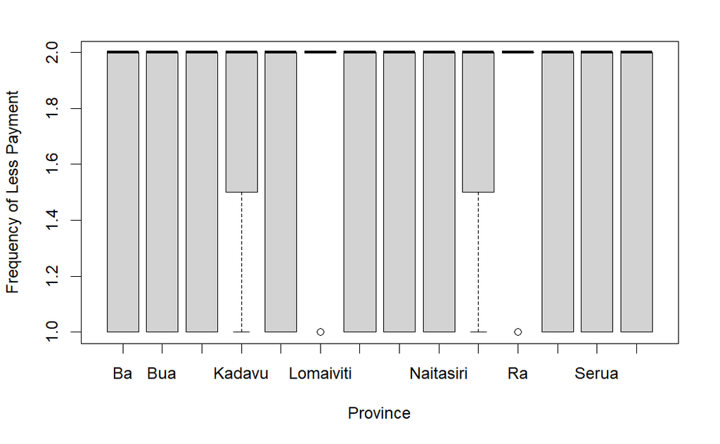

```r
boxplot(lesspay_2a ~ province, data = fiji_subset, xlab = "Province", ylab = "Frequency of Less Payment")
```

Below this line are things tried but don’t need

Let’s summarize the data and see how it looks first

```r
library(plyr)
count(fiji_subset, 'province')
```

[output not shown]

```r
#create a set of contingency tables
lesspay_2a <- with(fiji_subset, table(province, lesspay_2a))
typeofwork <- with(fiji_subset, table(province, typeofwork))
workinghrs <- with(fiji_subset, table(province, workinghrs))
pressured <- with(fiji_subset, table(province, pressured))
threatened <- with(fiji_subset, table(province, threatened))
harmed <- with(fiji_subset, table(province, harmed))
threatened_pay <- with(fiji_subset, table(province, threatened_pay))
threatened_report <- with(fiji_subset, table(province, threatened_report))
id_papers <- with(fiji_subset, table(province, id_papers))
comm_family <- with(fiji_subset, table(province, comm_family))
lesspay_11a <- with(fiji_subset, table(province, lesspay_11a))
workinghrs_11c <- with(fiji_subset, table(province, workinghrs_11c))
pressured_11d <- with(fiji_subset, table(province, pressured_11d))
threatened_11e <- with(fiji_subset, table(province, threatened_11e))
harmed_11f <- with(fiji_subset, table(province, harmed_11f))
threatened_pay_11g <- with(fiji_subset, table(province, threatened_pay_11g))
threatened_report_11h <- with(fiji_subset, table(province, threatened_report_11h))
id_papers_11i <- with(fiji_subset, table(province, id_papers_11i))
comm_family_11j <- with(fiji_subset, table(province, comm_family_11j))
comm_others_11k <- with(fiji_subset, table(province, comm_others_11k))
yes_number_12k <- with(fiji_subset, table(province, yes_number_12k))
```